# House Selling Prices

```r
library(tidyverse)
# library(car)
library(ggpubr)
library(pander)
library(DT)
```

## Analysis

### Introduction

This analysis predicts house prices using a Kaggle dataset and a regression model.

I cleaned the data and fitted the model.

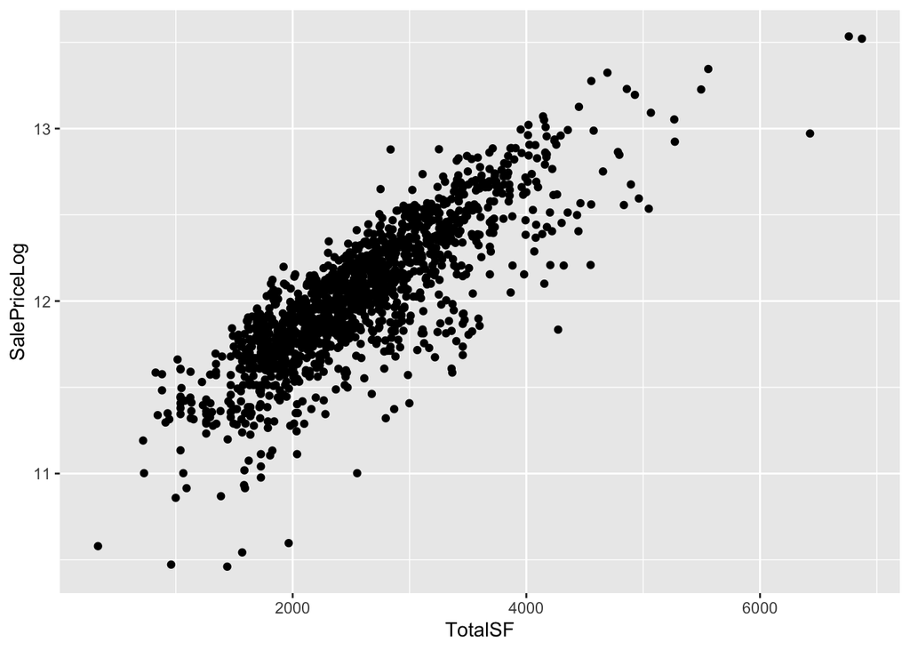

```r
dat <- read.csv("train.csv")

# datatable(dat, options=list(lengthMenu = c(10)), extensions="Buttons")
#
# datatable(head(dat, 20), options = list(
#   columnDefs = list(list(className = 'dt-center', targets = 5)),
#   pageLength = 5,
#   lengthMenu = c(5, 10, 15, 20)))


set.seed(121)

num_rows <- 1000 #1460 total
keep <- sample(1:nrow(dat), num_rows)

dat2 <- dat %>%
  mutate(
    TotalSF = `X1stFlrSF` + `X2ndFlrSF` + `TotalBsmtSF`,
    OverallQual = case_when(
           OverallQual >= 9 ~ "Qual9Up",
           OverallQual <= 4 ~ "Qual4Less",
           TRUE ~ as.character(paste0("Qual",OverallQual))),
    SalePriceLog = log(SalePrice),
    MSZoning2 = case_when(
        MSZoning %in% c("RH", "RL", "RM", "RP") ~ "ZoningR",
        MSZoning == "C (all)" ~ "ZoningC",
        TRUE ~paste0("Zoning", MSZoning)),
    GarageCars = case_when(
        GarageCars >= 3 ~ "Garage3Up",
        TRUE ~ as.character(paste0("Garage", GarageCars))),
    TotalSF = ifelse(TotalSF > 7000, base::mean(TotalSF), TotalSF),
    OverallQual = as.factor(OverallQual),
    GarageCars = as.factor(GarageCars),
    MSZoning2 = as.factor(MSZoning2)) %>%
  select(TotalSF, SalePriceLog,SalePrice, MSZoning2, GarageCars, OverallQual) %>%
  mutate(
    rownum = 1:n(), value = 1) %>%
    spread(OverallQual, value, fill = 0) %>%
    mutate(value = 1) %>%
    spread(MSZoning2, value, fill = 0) %>%
    mutate(value = 1) %>%
    spread(GarageCars, value, fill = 0)

mytrain <- dat2[keep, ] #Use this in the lm(..., data=mytrain)

mytest <- dat2[-keep, ] #Use this in the predict(..., newdata=mytest)

lm1 <- lm(SalePriceLog~
TotalSF
+Qual4Less
+Qual5
+Qual6
+Qual7
+Qual8
+Qual4Less:Garage2:TotalSF
+Qual5:Garage1:TotalSF
+Qual5:Garage2
+Qual6:Garage2
+Qual8:Garage3Up:TotalSF
,data = mytrain)

yht <- predict(lm1, newdata = mytest)

# Compute y-bar
ybar <- mean(mytest$SalePriceLog) #Yi is given by Ynew from the new sample of data

# Compute SSTO
SSTO <- sum( (mytest$SalePriceLog - ybar)^2 )

# Compute SSE for each model using y - yhat
SSEt <- sum( (mytest$SalePriceLog - yht)^2 )

  # Compute R-squared for each
  rst <- 1 - SSEt/SSTO

# Compute adjusted R-squared for each
n <- length(mytest$SalePriceLog) #sample size
pt <- length(coef(lm1)) #num. parameters in model
rsta <- 1 - (n-1)/(n-pt)*SSEt/SSTO

my_output_table <- data.frame(
    `Original R2`           = summary(lm1)$r.squared,
    `Orig. Adj. R-squared` = summary(lm1)$adj.r.squared,
    `Validation R-squared` = rst,
    `Validation Adj. R^2`  = rsta)

colnames(my_output_table) <- c("Original $R^2$", "Original Adj. $R^2$", "Validation $R^2$", "Validation Adj. $R^2$")

b <- coef(lm1)

dat3 <- dat2 %>%
  pivot_longer(cols = starts_with("Qual"), names_to = "OverallQual") %>%
  filter(value == 1) %>%
  select(-value) %>%
  pivot_longer(cols = starts_with("Garage"), names_to = "GarageCars") %>%
  filter(value == 1)%>%
  select(-value) %>%
  pivot_longer(cols = starts_with("Zoning"), names_to = "MSZoning") %>%
  filter(value == 1) %>%
  select(-value)

dat3 %>%
  mutate(GarageCars = case_when(
    GarageCars %in% c("Garage0", "Garage1", "Garage3Up") ~ "Garage013",
    TRUE ~ GarageCars
  )) %>%
  ggplot(aes(TotalSF, SalePriceLog))+
  geom_point()
```

### Interpretation

For each **incremental unit** in square footage, there is an average overall increase of **0.0232%** in the sale price. The correlation between the change in square footage and the slope value is **0.000232.**

Through the utilization of a graphing system, patterns in the data can be identified. The various graphs represent different scenarios based on the property’s **quality rating** and **garage status.**

Properties with a quality rating of **4** and a **two-car garage** exhibit a percentage change of **0.00774** per unit of total square footage, resulting in a total percentage change of **0.031%** per unit change in total square footage.

Properties with a quality rating of **5** and a **one-car garage** exhibit a percentage change of **0.029%** per unit of total square footage.

Properties with a quality rating of **8** and a **three-car garage** exhibit a percentage change of **0.027%** per unit of total square footage.

## Model Summary

### R-Squared Comparisson

```r
pander(my_output_table)
```

| Original $R^2$ | Original Adj. $R^2$ | Validation $R^2$ | Validation Adj. $R^2$ |
| --- | --- | --- | --- |
| 0.8239 | 0.8219 | 0.8137 | 0.8091 |

### Regression Summary

```r
pander(summary(lm1))
```

|  | Estimate | Std. Error | t value | Pr(>\|t\|) |
| --- | --- | --- | --- | --- |
| **(Intercept)** | 11.92 | 0.04582 | 260.1 | 0 |
| **TotalSF** | 0.0002321 | 9.788e-06 | 23.72 | 8.734e-99 |
| **Qual4Less** | -0.8828 | 0.03903 | -22.62 | 1.279e-91 |
| **Qual5** | -0.777 | 0.04463 | -17.41 | 2.029e-59 |
| **Qual6** | -0.6331 | 0.03632 | -17.43 | 1.585e-59 |
| **Qual7** | -0.3494 | 0.02984 | -11.71 | 9.358e-30 |
| **Qual8** | -0.2651 | 0.03364 | -7.88 | 8.618e-15 |
| **Qual5:Garage2** | 0.1877 | 0.03494 | 5.372 | 9.704e-08 |
| **Qual6:Garage2** | 0.1727 | 0.02426 | 7.116 | 2.131e-12 |
| **TotalSF:Qual4Less:Garage2** | 7.745e-05 | 1.971e-05 | 3.929 | 9.131e-05 |
| **TotalSF:Qual5:Garage1** | 5.749e-05 | 1.618e-05 | 3.554 | 0.000398 |
| **TotalSF:Qual8:Garage3Up** | 3.423e-05 | 8.559e-06 | 4 | 6.814e-05 |

Fitting linear model: SalePriceLog ~ TotalSF + Qual4Less + Qual5 + Qual6 + Qual7 + Qual8 + Qual4Less:Garage2:TotalSF + Qual5:Garage1:TotalSF + Qual5:Garage2 + Qual6:Garage2 + Qual8:Garage3Up:TotalSF

| Observations | Residual Std. Error | $R^2$ | Adjusted $R^2$ |
| --- | --- | --- | --- |
| 1000 | 0.1723 | 0.8239 | 0.8219 |

## graphing the model

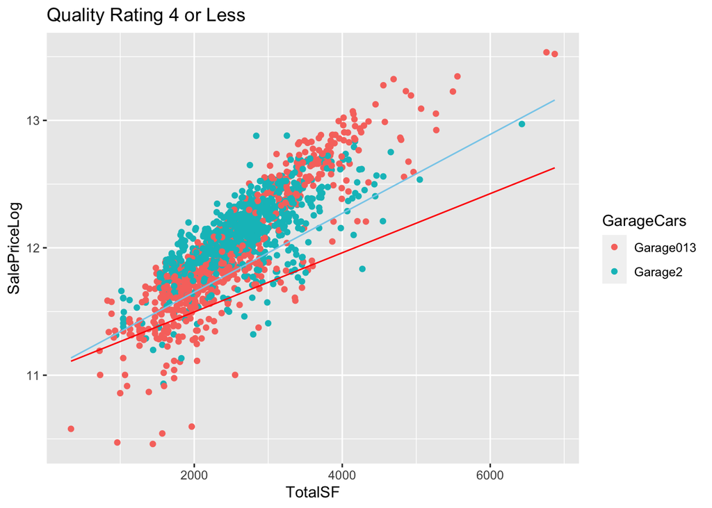

```r
p1 <- dat3 %>%
  mutate(GarageCars = case_when(
    GarageCars %in% c("Garage0", "Garage1", "Garage3Up") ~ "Garage013",
    TRUE ~ GarageCars
  )) %>%
  ggplot(aes(TotalSF, SalePriceLog, color = GarageCars))+
  geom_point()+
  stat_function(fun = function(x) (b[1] + b[3]) + b[2] * x + b[10] * x, color = "skyblue")+
  stat_function(fun = function(x) (b[1] + b[3]) + b[2] * x, color = "red")+
  labs(title = "Quality Rating 4 or Less")

p2 <- dat3%>%
  mutate(GarageCars = case_when(
    GarageCars %in% c("Garage0",  "Garage3Up") ~ "Garage03",
    TRUE ~ GarageCars
  )) %>%
  ggplot(aes(TotalSF, SalePriceLog, color = GarageCars))+
  geom_point()+
  stat_function(fun = function(x) (b[1] + b[4]) + b[2] * x + b[11] * x, color = "green")+
  stat_function(fun = function(x) (b[1] + b[4]) + b[2] * x, color = "firebrick")+
  stat_function(fun = function(x) (b[1] + b[4] + b[8]) + b[2] * x, color = "skyblue")+
  labs(title = "Quality Rating 5")

p3 <- dat3 %>%
  mutate(GarageCars = case_when(
    GarageCars %in% c("Garage0", "Garage1",  "Garage3Up") ~ "Garage013",
    TRUE ~ GarageCars
  )) %>%
  ggplot(aes(TotalSF, SalePriceLog, color = GarageCars))+
  geom_point()+
  stat_function(fun = function(x) (b[1] + b[5]) + b[2] * x + b[9], color = "skyblue")+
  stat_function(fun = function(x) (b[1] + b[5]) + b[2] * x, color = "firebrick")+
  labs(title = "Quality Rating 6")

 p4 <- dat3 %>%
  mutate(GarageCars = case_when(
    GarageCars %in% c("Garage0", "Garage1","Garage2",  "Garage3Up") ~ "AllGarageTypes",
    TRUE ~ GarageCars
  )) %>%
  ggplot(aes(TotalSF, SalePriceLog, color = GarageCars))+
  geom_point()+
  stat_function(fun = function(x) (b[1] + b[6]) + b[2] * x, color = "firebrick")+
  labs(title = "Quality Rating 7")

p5 <- dat3 %>%
  mutate(GarageCars = case_when(
    GarageCars %in% c("Garage0", "Garage1","Garage2") ~ "Garage012",
    TRUE ~ GarageCars
  )) %>%
  ggplot(aes(TotalSF, SalePriceLog, color = GarageCars))+
  geom_point()+
  stat_function(fun = function(x) (b[1] + b[7]) + b[2] * x, color = "firebrick")+
  stat_function(fun = function(x) (b[1] + b[7]) + b[2] * x + b[12] * x, color = "skyblue")+
  labs(title = "Quality Rating 8")

p1
```

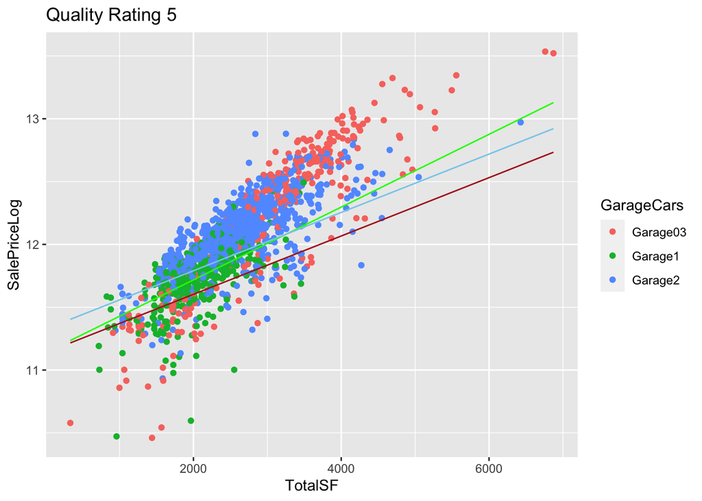

```r
p2
```

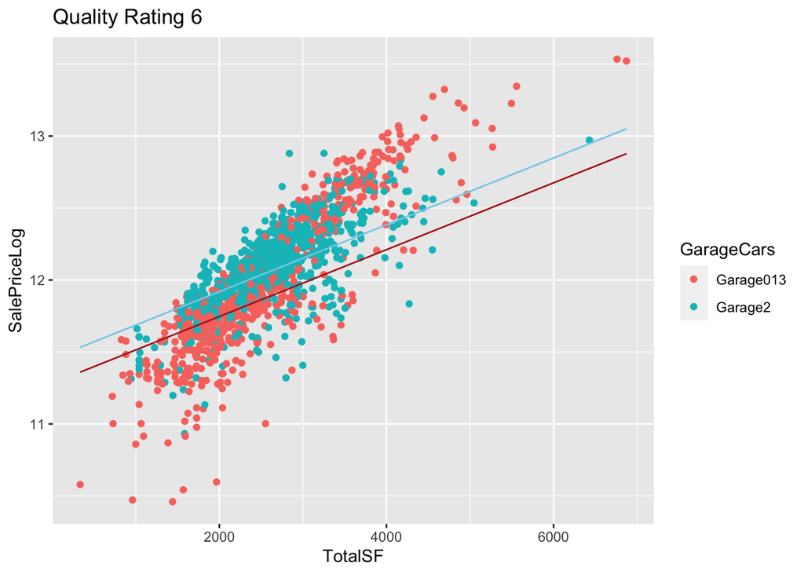

```r
p3
```

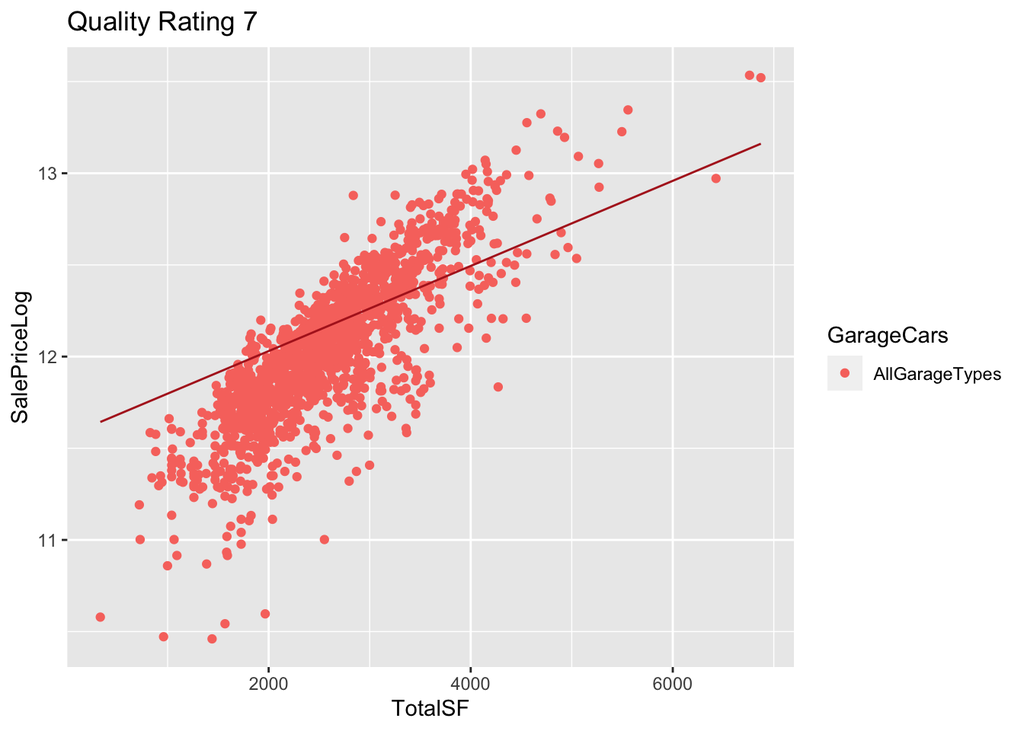

```r
p4
```

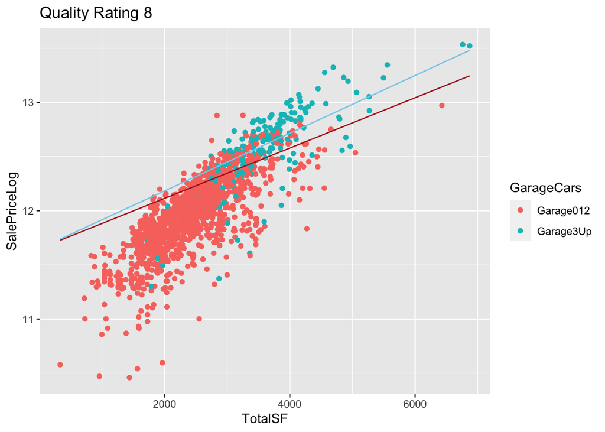

```r
p5
```

```r
# dat3 %>%
#   ggplot(aes(TotalSF, SalePriceLog, color = GarageCars))+
#   geom_point()+
#   labs(title = "Quality Rating 4 or Less")+
#   facet_wrap(~interaction(
#      OverallQual
#     ,GarageCars
#     ,MSZoning
#   ))#, labeller="label_both"))
```

## Data

### Raw Data

```r
dat
```

| Id | MSSubClass | MSZoning | LotFrontage | LotArea | Street | Alley | LotShape | LandContour | Utilities | LotConfig | LandSlope | Neighborhood | Condition1 | Condition2 | BldgType | HouseStyle | OverallQual | OverallCond | YearBuilt | YearRemodAdd | RoofStyle | RoofMatl | Exterior1st | Exterior2nd | MasVnrType | MasVnrArea | ExterQual | ExterCond | Foundation | … |
| --- | --- | --- | --- | --- | --- | --- | --- | --- | --- | --- | --- | --- | --- | --- | --- | --- | --- | --- | --- | --- | --- | --- | --- | --- | --- | --- | --- | --- | --- | --- |
| 1 | 60 | RL | 65 | 8450 | Pave | NA | Reg | Lvl | AllPub | Inside | Gtl | CollgCr | Norm | Norm | 1Fam | 2Story | 7 | 5 | 2003 | 2003 | Gable | CompShg | VinylSd | VinylSd | BrkFace | 196 | Gd | TA | PConc | … |
| 2 | 20 | RL | 80 | 9600 | Pave | NA | Reg | Lvl | AllPub | FR2 | Gtl | Veenker | Feedr | Norm | 1Fam | 1Story | 6 | 8 | 1976 | 1976 | Gable | CompShg | MetalSd | MetalSd | None | 0 | TA | TA | CBlock | … |
| 3 | 60 | RL | 68 | 11250 | Pave | NA | IR1 | Lvl | AllPub | Inside | Gtl | CollgCr | Norm | Norm | 1Fam | 2Story | 7 | 5 | 2001 | 2002 | Gable | CompShg | VinylSd | VinylSd | BrkFace | 162 | Gd | TA | PConc | … |
| 4 | 70 | RL | 60 | 9550 | Pave | NA | IR1 | Lvl | AllPub | Corner | Gtl | Crawfor | Norm | Norm | 1Fam | 2Story | 7 | 5 | 1915 | 1970 | Gable | CompShg | Wd Sdng | Wd Shng | None | 0 | TA | TA | BrkTil | … |
| 5 | 60 | RL | 84 | 14260 | Pave | NA | IR1 | Lvl | AllPub | FR2 | Gtl | NoRidge | Norm | Norm | 1Fam | 2Story | 8 | 5 | 2000 | 2000 | Gable | CompShg | VinylSd | VinylSd | BrkFace | 350 | Gd | TA | PConc | … |
| 6 | 50 | RL | 85 | 14115 | Pave | NA | IR1 | Lvl | AllPub | Inside | Gtl | Mitchel | Norm | Norm | 1Fam | 1.5Fin | 5 | 5 | 1993 | 1995 | Gable | CompShg | VinylSd | VinylSd | None | 0 | TA | TA | Wood | … |
| 7 | 20 | RL | 75 | 10084 | Pave | NA | Reg | Lvl | AllPub | Inside | Gtl | Somerst | Norm | Norm | 1Fam | 1Story | 8 | 5 | 2004 | 2005 | Gable | CompShg | VinylSd | VinylSd | Stone | 186 | Gd | TA | PConc | … |
| 8 | 60 | RL | NA | 10382 | Pave | NA | IR1 | Lvl | AllPub | Corner | Gtl | NWAmes | PosN | Norm | 1Fam | 2Story | 7 | 6 | 1973 | 1973 | Gable | CompShg | HdBoard | HdBoard | Stone | 240 | TA | TA | CBlock | … |
| 9 | 50 | RM | 51 | 6120 | Pave | NA | Reg | Lvl | AllPub | Inside | Gtl | OldTown | Artery | Norm | 1Fam | 1.5Fin | 7 | 5 | 1931 | 1950 | Gable | CompShg | BrkFace | Wd Shng | None | 0 | TA | TA | BrkTil | … |
| 10 | 190 | RL | 50 | 7420 | Pave | NA | Reg | Lvl | AllPub | Corner | Gtl | BrkSide | Artery | Artery | 2fmCon | 1.5Unf | 5 | 6 | 1939 | 1950 | Gable | CompShg | MetalSd | MetalSd | None | 0 | TA | TA | BrkTil | … |

[output cut: 1450 more lines]

### Clean Data

```r
dat2
```

| TotalSF | SalePriceLog | SalePrice | rownum | Qual4Less | Qual5 | Qual6 | Qual7 | Qual8 | Qual9Up | ZoningC | ZoningFV | ZoningR | Garage0 | Garage1 | Garage2 | Garage3Up |
| --- | --- | --- | --- | --- | --- | --- | --- | --- | --- | --- | --- | --- | --- | --- | --- | --- |
| 2566.000 | 12.24769 | 208500 | 1 | 0 | 0 | 0 | 1 | 0 | 0 | 0 | 0 | 1 | 0 | 0 | 1 | 0 |
| 2524.000 | 12.10901 | 181500 | 2 | 0 | 0 | 1 | 0 | 0 | 0 | 0 | 0 | 1 | 0 | 0 | 1 | 0 |
| 2706.000 | 12.31717 | 223500 | 3 | 0 | 0 | 0 | 1 | 0 | 0 | 0 | 0 | 1 | 0 | 0 | 1 | 0 |
| 2473.000 | 11.84940 | 140000 | 4 | 0 | 0 | 0 | 1 | 0 | 0 | 0 | 0 | 1 | 0 | 0 | 0 | 1 |
| 3343.000 | 12.42922 | 250000 | 5 | 0 | 0 | 0 | 0 | 1 | 0 | 0 | 0 | 1 | 0 | 0 | 0 | 1 |
| 2158.000 | 11.87060 | 143000 | 6 | 0 | 1 | 0 | 0 | 0 | 0 | 0 | 0 | 1 | 0 | 0 | 1 | 0 |
| 3380.000 | 12.63460 | 307000 | 7 | 0 | 0 | 0 | 0 | 1 | 0 | 0 | 0 | 1 | 0 | 0 | 1 | 0 |
| 3197.000 | 12.20607 | 200000 | 8 | 0 | 0 | 0 | 1 | 0 | 0 | 0 | 0 | 1 | 0 | 0 | 1 | 0 |
| 2726.000 | 11.77452 | 129900 | 9 | 0 | 0 | 0 | 1 | 0 | 0 | 0 | 0 | 1 | 0 | 0 | 1 | 0 |
| 2068.000 | 11.67844 | 118000 | 10 | 0 | 1 | 0 | 0 | 0 | 0 | 0 | 0 | 1 | 0 | 1 | 0 | 0 |

[output cut: 1450 more lines]